# Fst variation across human traits

##### Ridges

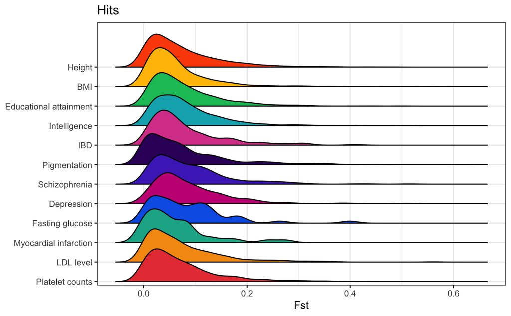

```r
one = fst_out %>%
  dplyr::filter(hit_control == "hit") %>%
  dplyr::mutate(phenotype = factor(phenotype, levels = rev(trait_levels_verb))) %>%
  ggplot() +
    geom_density_ridges2(mapping = aes(x = Fst, y = phenotype, fill = phenotype),
                         scale = 2) +
    scale_fill_manual(values = pal_primary) +
    ylab(label = NULL) +
    theme_bw() +
    guides(fill = F) +
    scale_y_discrete(expand = expand_scale(add = c(0.2, 2.3))) +
    ggtitle("Hits")

#two = fst_out %>%
#  dplyr::filter(hit_control == "control") %>%
#  dplyr::mutate(phenotype = factor(phenotype, levels = rev(trait_levels_verb))) %>%
#  ggplot() +
#    geom_density_ridges2(mapping = aes(x = Fst, y = phenotype, fill = phenotype),
#                         scale = 2) +
#    scale_fill_manual(values = pal_secondary) +
#    ylab(label = NULL) +
#    theme_bw() +
#    guides(fill = F) +
#    scale_y_discrete(expand = expand_scale(add = c(0.2, 2.3))) +
#    ggtitle("Controls")

one
```

```r
#two
```

```r
ggsave(file.path(plot_path, "ridges_hits.svg"),
       device = "svg",
       height = 12,
       width = 20)
```

```r
ggsave(file.path(plot_path, "ridges_rndm.svg"),
       device = "svg",
       height = 12,
       width = 20)
```

### Tests

#### Median, 80 and 90 percentiles, KS test, and MW test

Rationale:

1. Get the median, and 0.8 and 0.9 percentiles for the *Fst* density of each trait.
2. Run one-sided Mann-Whitney tests using `Height` as the reference against each of the other traits.
3. Run one-sided Kolmogorov-Smirnov tests using `Height` as the reference against each of the other traits.
4. Determine which tests to use to confirm the differences apparent in the forms of the density curves.

```r
final_list = split(fst_out, f = fst_out$hit_control)
final_list = lapply(final_list, function(dataset){
  split_data = split(dataset, f = dataset$phenotype)

  out = lapply(split_data, function(pheno){
    stats = list()

    # Get median and 90 percentile
    stats[["stats"]] = c("median" = median(pheno$Fst),
                         quantile(pheno$Fst, probs = 0.8),
                         quantile(pheno$Fst, probs = 0.9))

    # Get Mann-Whitney results
    stats[["final_list"]] = wilcox.test(x = split_data[["Height"]]$Fst,
                                    y = pheno$Fst,
                                    alternative = "less",
                                    paired = F,
                                    conf.int = T)

    # Get KS results
    stats[["ks_out"]] = ks.test(x = split_data[["Height"]]$Fst,
                                y = pheno$Fst,
                                alternative = "greater")

    return(stats)
  })# %>%
    #dplyr::bind_rows(.id = "phenotype")


  return(out)

})

# Collapse into DF
final_df = lapply(final_list, function(dataset){
  out = lapply(dataset, function(pheno){
    # Put key data into data frame
    df = c("MEDIAN" = pheno[["stats"]][["median"]],
           "80%" = pheno[["stats"]][["80%"]],
           "90%" = pheno[["stats"]][["90%"]],
           pheno[["final_list"]]$statistic,
           "P_MW" = pheno[["final_list"]]$p.value,
           "CONF_LOWER" = pheno[["final_list"]]$conf.int[1],
           "CONF_UPPER" = pheno[["final_list"]]$conf.int[2],
           pheno[["ks_out"]]$statistic,
           "P_KS" = pheno[["ks_out"]]$p.value)

    return(df)
  }) %>%
    dplyr::bind_rows(.id = "PHENO")

  return(out)
}) %>%
  dplyr::bind_rows(.id = "HIT_CONTROL")

# Factor
final_df$PHENO <- factor(final_df$PHENO, levels = trait_levels_verb)
final_df$HIT_CONTROL = factor(final_df$HIT_CONTROL, levels = hit_control_levels)

# Output table
final_df %>%
  dplyr::filter(PHENO != "Height" & HIT_CONTROL == "hit") %>%
  dplyr::select(!HIT_CONTROL) %>%
  knitr::kable()
```

[output not shown]

### Final *Fst* density plots for hits

Some options for the figure.

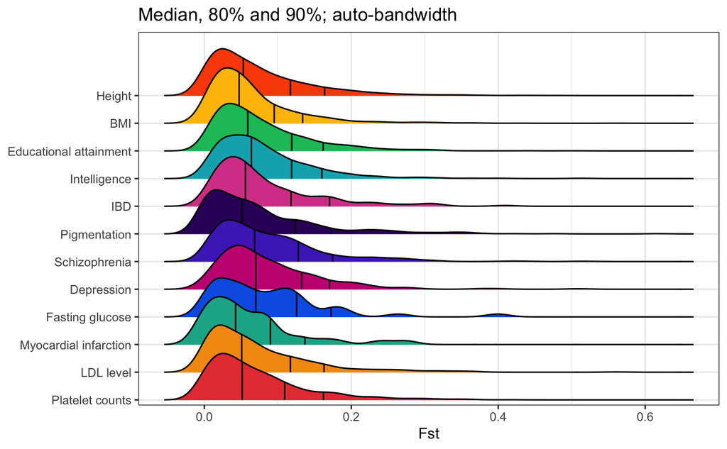

```r
fst_out %>%
  dplyr::filter(hit_control == "hit") %>%
  dplyr::mutate(phenotype = factor(phenotype, levels = rev(trait_levels_verb))) %>%
  ggplot(aes(Fst, phenotype, fill = phenotype)) +
    stat_density_ridges(geom = "density_ridges_gradient",
                        scale = 2,
                        calc_ecdf = TRUE,
                        quantiles = c(0.5, 0.8, 0.9),
                        quantile_lines = T) +
  scale_fill_manual(values = pal_primary) +
  guides(fill = F) +
  theme_bw() +
  scale_y_discrete(expand = expansion(add = c(0.2, 2.3))) +
  ylab(NULL) +
  ggtitle("Median, 80% and 90%; auto-bandwidth")
```

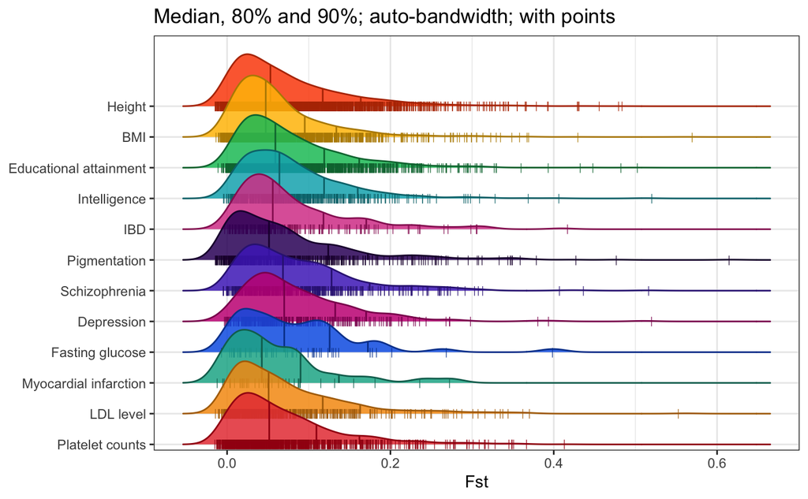

```r
# Automatic bandwidth
fst_out %>%
  dplyr::filter(hit_control == "hit") %>%
  dplyr::mutate(phenotype = factor(phenotype, levels = rev(trait_levels_verb))) %>%
  ggplot(aes(Fst, phenotype, fill = phenotype, colour = phenotype)) +
    geom_density_ridges(scale = 2,
                        calc_ecdf = TRUE,
                        quantiles = c(0.5, 0.8, 0.9),
                        quantile_lines = T,
                        jittered_points = TRUE,
                        point_shape = '|', alpha = 0.85, point_size = 2,
                        position = position_points_jitter(width = 0.01, height = 0)) +
  scale_fill_manual(values = pal_primary) +
  scale_colour_manual(values = pal_secondary) +
  guides(fill = F, colour = F) +
  theme_bw() +
  scale_y_discrete(expand = expansion(add = c(0.2, 2.3))) +
  ylab(NULL) +
  ggtitle("Median, 80% and 90%; auto-bandwidth; with points")
```

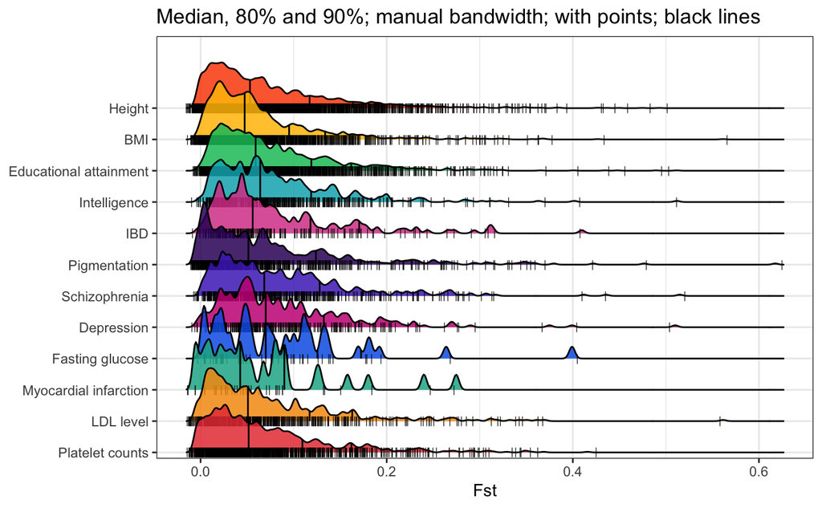

```r
# Manually-set bandwidth
fst_out %>%
  dplyr::filter(hit_control == "hit") %>%
  dplyr::mutate(phenotype = factor(phenotype, levels = rev(trait_levels_verb))) %>%
  ggplot(aes(Fst, phenotype, fill = phenotype)) +
    geom_density_ridges(scale = 2,
                        bandwidth = 0.003,
                        calc_ecdf = TRUE,
                        quantiles = c(0.5, 0.8, 0.9),
                        quantile_lines = T,
                        jittered_points = TRUE,
                        point_shape = '|', alpha = 0.85, point_size = 2,
                        position = position_points_jitter(width = 0.01, height = 0)) +
  scale_fill_manual(values = pal_primary) +
 # scale_colour_manual(values = pal_secondary) +
  guides(fill = F, colour = F) +
  theme_bw() +
  scale_y_discrete(expand = expansion(add = c(0.2, 2.3))) +
  ylab(NULL) +
  ggtitle("Median, 80% and 90%; manual bandwidth; with points; black lines")
```

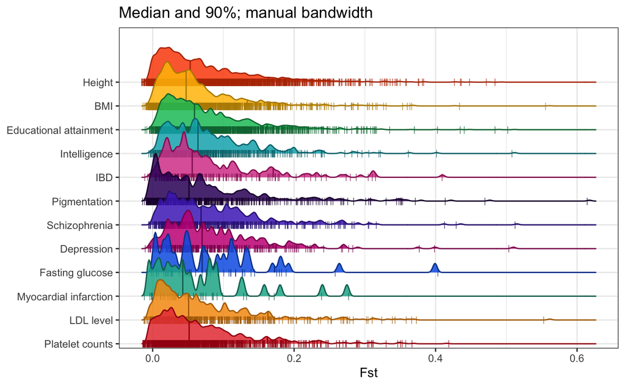

```r
# Manually-set bandwidth
fst_out %>%
  dplyr::filter(hit_control == "hit") %>%
  dplyr::mutate(phenotype = factor(phenotype, levels = rev(trait_levels_verb))) %>%
  ggplot(aes(Fst, phenotype, fill = phenotype, colour = phenotype)) +
    geom_density_ridges(scale = 2,
                        bandwidth = 0.003,
                        calc_ecdf = TRUE,
                        quantiles = c(0.5, 0.9),
                        quantile_lines = T,
                        jittered_points = TRUE,
                        point_shape = '|', alpha = 0.85, point_size = 2,
                        position = position_points_jitter(width = 0.01, height = 0)) +
  scale_fill_manual(values = pal_primary) +
  scale_colour_manual(values = pal_secondary) +
  guides(fill = F, colour = F) +
  theme_bw() +
  scale_y_discrete(expand = expansion(add = c(0.2, 2.3))) +
  ylab(NULL) +
  ggtitle("Median and 90%; manual bandwidth")
```

```r
ggsave(file.path(plot_path, "ridges_rndm.svg"),
       device = "svg",
       width = 14,
       height = 15)
```